# Notebook 1: Downloading Migration Data from GBIF

## Step 1: Get occurrence data from the Global Biodiversity Information Facility (GBIF)

For your species migration portfolio assignment, you will need to acquire GBIF data for a different species. I recommend choosing a terrestrial species, as this will work best with the ecoregions data used in the assignment.

## Set up

In the imports cell, we’ve included some packages that you will need. Add imports for additional packages that will help you to:

1. Work with reproducible file paths
2. Work with tabular data

```python
### Imoport libraries for all portfolio post steps

import time ### time processing steps
import zipfile ### read and extract .zip folders
from getpass import getpass ### handles sensitive inputs like passwords and API tokens
from glob import glob ### function for finding file paths
import requests ### make requests to websites and web APIs

### GBIF packages
import pygbif.occurrences as occ ### get GBIF occurrence data
import pygbif.species as species ### deals with species names

### import additional packages you'll need

### import folder/file management
import os
import pathlib
import shutil

### import for tabular data
import pandas as pd

### import for geo-vector data
import geopandas as gpd

### access gbif data for project
import earthpy as et

### libraries for dynamic mapping

### manage coordinate system
import cartopy.crs as ccrs

### customize dynamic plot
import panel as pn
pn.extension()


### generte plot from geodataframe
import hvplot.pandas
import holoviews as hv
pn.extension()
hv.extension("bokeh")

### get month names
import calendar

### import shapely
import shapely

### Installing troubleshooting packages for data and plot
%pip install pygbif
%pip install -U jupyter_bokeh

### confirm imports
print("Imports successful")
```

```
Imports successful
```

```python
### Importing different libraries to troubleshoot error messages with Dr. Jones
import sys


print("Notebook Python:", sys.executable)
print("Shapely location:", shapely.__file__)

import warnings

warnings.filterwarnings(
    "ignore",
    message=".*invalid value encountered in create_collection.*",
    category=RuntimeWarning
)

### confirm imports
print("Imports successful")
```

```
Notebook Python: /Users/haydensimmons/Downloads/Downloads/envs/earth-analytics-python/bin/python
Shapely location: /Users/haydensimmons/Downloads/Downloads/envs/earth-analytics-python/lib/python3.11/site-packages/shapely/__init__.py
Imports successful
```

### Step 1A: Make a GBIF account

You will need to make a free account with [GBIF](https://www.gbif.org/) to access their data. Keep track of your username, password, and the email address you sign up with, as you'll need all of this later!

You will need a (free) [GBIF account](https://www.gbif.org/) to complete this challenge. Then, run the following code to enter your credentials for the rest of your session.

This code is **interactive**, meaning that it will **ask you for a response**! The prompt can sometimes be hard to see if you are using VSCode – it appears at the **top** of your editor window.

**Tips:**

1. If you need to save credentials across multiple sessions, you can consider loading them in from a file like a `.env`, but make sure to add it to .gitignore so you don’t commit your credentials to your repository!
2. If you accidentally enter your credentials wrong, you can set `reset = True` instead of `reset = False`.

**Warning** Your email address **must** match the email you used to sign up for GBIF!

```python
### change this to reset = False after you run this chunk the first time
reset = False

####--------------------------------------####
#### DO NOT MODIFY THE REST OF THIS CODE! ####
####--------------------------------------####
### This code asks for your credentials and saves it for the rest of the session.
### NEVER put your credentials into your code!!!!
### GBIF needs a username, password, and email

### request and store username
if (not ('GBIF_USER'  in os.environ)) or reset:
    os.environ['GBIF_USER'] = input('GBIF username:')

### securely request and store password
if (not ('GBIF_PWD'  in os.environ)) or reset:
    os.environ['GBIF_PWD'] = getpass('GBIF password:')

### request and store account email address
if (not ('GBIF_EMAIL'  in os.environ)) or reset:
    os.environ['GBIF_EMAIL'] = input('GBIF email:')
```

### Step 1B: Create a project folder and data directories

The code below will help you get started with making a folder for your data to live in:

```python
### create data directory
data_dir = os.path.join(

    ### point to your home directory
    pathlib.Path.home(),

    ### nest the data in the folder where your assignments live
    'earth-analytics',
    'data',
    'monarch-migration-post')

### make the directory
os.makedirs(data_dir, exist_ok = True)

### define directory for the gbif data
gbif_dir = os.path.join(data_dir, 'gbif')

### make the directory
os.makedirs(gbif_dir, exist_ok = True)

### check data paths to confirm they exist
data_dir
gbif_dir
```

```
'/Users/haydensimmons/earth-analytics/data/monarch-migration-post/gbif'
```

### STEP 1C: Get the taxon key from GBIF

One of the tricky parts about getting occurrence data from GBIF is that species often have multiple names in different contexts. Luckily, GBIF also provides a Name Backbone service that will translate scientific and colloquial names into unique identifiers. GBIF calls these identifiers **taxon keys**:

1. Put the species name into the correct location in the code below.
2. Examine the object you get back from the species query. What part of it do you think might be the taxon key
3. Extract and save the taxon key.

```python
### define the species name you will be using
backbone = species.name_backbone(scientificName = "Danaus plexippus" )

### check it out
backbone
```

```
{'usage': {'key': '5133088',
  'name': 'Danaus plexippus (Linnaeus, 1758)',
  'canonicalName': 'Danaus plexippus',
  'authorship': '(Linnaeus, 1758)',
  'rank': 'SPECIES',
  'code': 'ZOOLOGICAL',
  'status': 'ACCEPTED',
  'genericName': 'Danaus',
  'specificEpithet': 'plexippus',
  'type': 'SCIENTIFIC',
  'formattedName': '<i>Danaus</i> <i>plexippus</i> (Linnaeus, 1758)'},
 'classification': [{'key': '1', 'name': 'Animalia', 'rank': 'KINGDOM'},
  {'key': '54', 'name': 'Arthropoda', 'rank': 'PHYLUM'},
  {'key': '216', 'name': 'Insecta', 'rank': 'CLASS'},
  {'key': '797', 'name': 'Lepidoptera', 'rank': 'ORDER'},
  {'key': '7017', 'name': 'Nymphalidae', 'rank': 'FAMILY'},
  {'key': '5133087', 'name': 'Danaus', 'rank': 'GENUS'},
  {'key': '5133088', 'name': 'Danaus plexippus', 'rank': 'SPECIES'}],
 'diagnostics': {'matchType': 'EXACT',
  'confidence': 99,
  'timeTaken': 8,
  'timings': {'nameNRank': 0,
   'sciNameMatch': 8,
   'nameParse': 0,
   'luceneMatch': 8}},
 'additionalStatus': [{'clbDatasetKey': '53131',
   'datasetAlias': 'IUCN',
   'datasetKey': '19491596-35ae-4a91-9a98-85cf505f1bd3',
   'status': 'LEAST_CONCERN',
   'statusCode': 'LC',
   'sourceId': '159971'}],
 'synonym': False}
```

Depending on the output from "backbone," you may need to modify the column in the code below to use 'usageKey' or another column:

```python
### pull out the species key
species_key = backbone['usage']['key']
species_key
```

```
'5133088'
```

### Step 1D: Download data from GBIF

Downloading GBIF data is a multi-step process. However, we’ve provided you with a chunk of code that handles the API communications and caches the download. You’ll still need to customize your search.

Submit a request to GBIF using the following steps:

```python
### set file name for download
gbif_monarch_mig = os.path.join(gbif_dir, '*.csv')

### set the code to only download your data the first time you run this chunk (since it can be slow)
if not glob(gbif_monarch_mig):

    ### only submit one request
    if not 'GBIF_DOWNLOAD_KEY' in os.environ:

        ### submit a request to GBIF
        gbif_query = occ.download([

            ### add your species key
            f"speciesKey = {species_key}",

            ### filter out results without geographic coordinates
            'hasCoordinate = True',

            ### choose a year to include
            f'year = 2023',
        ])

        ### grab the first result
        os.environ['GBIF_DOWNLOAD_KEY'] = gbif_query[0]

    ### wait for the download to build
    download_key = os.environ['GBIF_DOWNLOAD_KEY']

    ### use the occurrence command module in pygbif to get the metadata
    wait = occ.download_meta(download_key)['status']

    ### check if the status of the download = "SUCCEEDED"
    while not wait=='SUCCEEDED':
        wait = occ.download_meta(download_key)['status']

        ### wait before re-querying the API
        time.sleep(5)

    ### download GBIF data when it's ready
    download_info = occ.download_get(
        os.environ['GBIF_DOWNLOAD_KEY'],
        path = gbif_dir)

    ### unzip GBIF data using the zipfile package
    with zipfile.ZipFile(download_info['path']) as download_zip:
        download_zip.extractall(path = gbif_dir)

### find the extracted .csv file path (take the first result)
gbif_path = glob(gbif_monarch_mig)[0]
```

You might notice that the GBIF data filename isn’t very **descriptive**. At this point, you may want to clean up your data directory so that you know what the file is later on!

1. Replace ‘your-gbif-filename’ with a descriptive name.
2. Run the cell.
3. Check your data folder. Is it organized the way you want?

Tip: you can use the `shutil` package to programmatically rename the file.

```python
### give the download a descriptive name
new_gbif_monarch_mig = pathlib.Path(gbif_dir) / 'monarch-migration-gbif.csv'

### move file to descriptive path
shutil.move(gbif_path, new_gbif_monarch_mig)
```

```
PosixPath('/Users/haydensimmons/earth-analytics/data/monarch-migration-post/gbif/monarch-migration-gbif.csv')
```

### Step 1E: Load the GBIF data into Python

Just like you did when wrangling your data from the data subset, you’ll need to load your GBIF data and convert it to a GeoDataFrame.

```python
### load the GBIF data
mon_mig_gbif_df = pd.read_csv(
    new_gbif_monarch_mig,

    ### define delimiter in data set
    delimiter = '\t',

    ### set index identifier
    index_col = 'gbifID',

    ### subset columns
    usecols = ['gbifID', 'decimalLatitude', 'decimalLongitude', 'month']
)
### check out the data
mon_mig_gbif_df.head()
```

| gbifID | decimalLatitude | decimalLongitude | month |
| --- | --- | --- | --- |
| 6583908330 | -31.971842 | 151.062433 | 11.0 |
| 6579952454 | 43.643638 | -79.466724 | 9.0 |
| 6579941844 | 42.266187 | -83.679808 | 9.0 |
| 6579892376 | 43.448995 | -80.495613 | 9.0 |
| 6579792383 | 25.647556 | -100.356821 | 1.0 |

```python
### convert the dataframe to a geodataframe
mon_mig_gbif_gdf = (
    gpd.GeoDataFrame(
        mon_mig_gbif_df,

        ### set geometry for geodataframe from lat/lon of GBIF record
        geometry = gpd.points_from_xy(
            mon_mig_gbif_df.decimalLongitude,
            mon_mig_gbif_df.decimalLatitude),

        ### set the coordinate reference system
        crs = "EPSG:4326")

    ### select the desired columns
    [['month', 'geometry']]
)

### check out the geodataframe
mon_mig_gbif_gdf
```

| gbifID | month | geometry |
| --- | --- | --- |
| 6583908330 | 11.0 | POINT (151.06243 -31.97184) |
| 6579952454 | 9.0 | POINT (-79.46672 43.64364) |
| 6579941844 | 9.0 | POINT (-83.67981 42.26619) |
| 6579892376 | 9.0 | POINT (-80.49561 43.449) |
| 6579792383 | 1.0 | POINT (-100.35682 25.64756) |
| ... | ... | ... |
| 4507686934 | 1.0 | POINT (138.69976 -34.90042) |
| 4507683244 | 1.0 | POINT (-81.7309 26.09927) |
| 4507683217 | 1.0 | POINT (-112.03166 33.70651) |
| 4507682218 | 1.0 | POINT (-122.44422 37.48382) |
| 4507681255 | 1.0 | POINT (-80.87425 25.17854) |

43397 rows × 2 columns

# Notebook 2: Normalizing and Plotting Monarch Migration Patterns

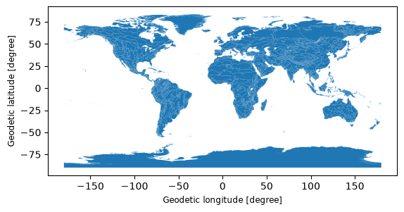

```python
### aquire ecoregion data for plot

### get url for ecoregions
ecoreg_url = ("https://storage.googleapis.com/"
       "teow2016/Ecoregions2017.zip")

### name the ecoregions directory name and file name
ecoreg_dir = os.path.join(data_dir, "ecoregion")

### make the ecoregions directory
os.makedirs(ecoreg_dir, exist_ok = True)

### join ecoregions shapefile path
ecoreg_path = os.path.join(ecoreg_dir, "ecoregions.shp")

### download the data once
if not os.path.exists(ecoreg_path):

       ### open file at url
       ecoreg_gdf = gpd.read_file(ecoreg_url)

       ### save to the defined filepath
       ecoreg_gdf.to_file(ecoreg_path)

### open up the ecoregions boundaries
ecoreg_gdf = gpd.read_file(ecoreg_path)

# plot the ecoregions quickly to check download
ecoreg_gdf.plot()
```

```python
### join the gbif observations to the ecoregion polygons
gbif_ecoregion_gdf = (
    ecoreg_gdf

    ### match the CRS of the gbif data and the ecoregions
    .to_crs(mon_mig_gbif_gdf.crs)

    ### find ecoregion for each observation
    .sjoin(
        mon_mig_gbif_gdf,

        ### type of database join
        how = 'inner',


        predicate = 'contains')

    ### any additional manipulations you want to do
    ### (renaming columns, etc)
    [['OBJECTID', 'month']]

    ### rename columns for organization
    .rename(columns = {'OBJECTID': 'ecoregion'})
)

### check it out
gbif_ecoregion_gdf
```

|  | ecoregion | month |
| --- | --- | --- |
| 16 | 17.0 | 7.0 |
| 16 | 17.0 | 9.0 |
| 16 | 17.0 | 8.0 |
| 16 | 17.0 | 8.0 |
| 16 | 17.0 | 10.0 |
| ... | ... | ... |
| 837 | 843.0 | 11.0 |
| 837 | 843.0 | 7.0 |
| 837 | 843.0 | 7.0 |
| 837 | 843.0 | 9.0 |
| 838 | 844.0 | 11.0 |

41669 rows × 2 columns

```python
### summarize the occurrences by ecoregion/month combination
mon_occurrence_df = (
    gbif_ecoregion_gdf

    ### group by each ecoregion and month
    .groupby(['ecoregion', 'month'])

    ### and count the number of occurrences
    .agg(occurrences = ('ecoregion', 'count'))
)

### get rid of rare observations (which are possibly misidentifications)
mon_occurrence_df = mon_occurrence_df[mon_occurrence_df.occurrences > 1]

### calculate the mean # observations by ecoregion
mean_occurrences_by_ecoregion = (
    mon_occurrence_df
    .groupby('ecoregion')
    .mean()
)

### calculate the mean # observations by month
mean_mon_occurrences_by_month = (
    mon_occurrence_df
    .groupby('month')
    .mean()
)

### make sure everything looks right
mean_mon_occurrences_by_month
```

| month | occurrences |
| --- | --- |
| 1.0 | 17.777778 |
| 2.0 | 20.791667 |
| 3.0 | 20.844828 |
| 4.0 | 30.579710 |
| 5.0 | 23.662500 |
| 6.0 | 36.779070 |
| 7.0 | 76.641304 |
| 8.0 | 89.030928 |
| 9.0 | 75.322222 |
| 10.0 | 56.141176 |
| 11.0 | 30.421053 |
| 12.0 | 23.156250 |

```python
### normalize by space and time for sampling effort
mon_occurrence_df['norm_occurrences'] = (
    mon_occurrence_df
    / mean_occurrences_by_ecoregion
    / mean_mon_occurrences_by_month

)

### check it out
mon_occurrence_df
```

| ecoregion | month | occurrences | norm_occurrences |
| --- | --- | --- | --- |
| 17.0 | 5.0 | 4 | 0.005306 |
|  | 6.0 | 17 | 0.014509 |
|  | 7.0 | 57 | 0.023346 |
|  | 8.0 | 72 | 0.025385 |
|  | 9.0 | 48 | 0.020004 |
| ... | ... | ... | ... |
| 810.0 | 2.0 | 5 | 0.068709 |
|  | 8.0 | 2 | 0.006418 |
|  | 10.0 | 5 | 0.025446 |
| 839.0 | 7.0 | 4 | 0.013048 |
| 843.0 | 7.0 | 2 | 0.013048 |

899 rows × 2 columns

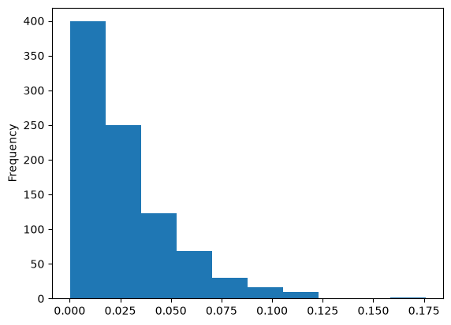

```python
### check histogram(for fun)
mon_occurrence_df.norm_occurrences.plot.hist()
```

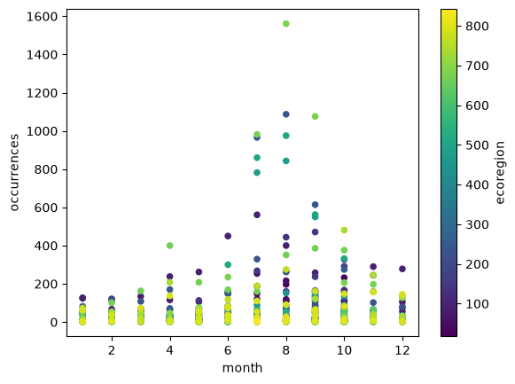

```python
### check scatterplot (for fun)
mon_occurrence_df.reset_index().plot.scatter(
    x = 'month',
    y = 'occurrences',
    c = 'ecoregion'
)
```

```python
### simplify the geometry to speed up processing
ecoreg_gdf.geometry = ecoreg_gdf.simplify(
    0.05, preserve_topology = False
)

### change the CRS to Mercator for mapping
ecoreg_gdf = ecoreg_gdf.to_crs(ccrs.Mercator())

### check that the plot runs in a reasonable amount of time
ecoreg_gdf.hvplot(geo = True, crs = ccrs.Mercator())
```

[output not shown]

```python
### check gdf columns to see if I need to rename
ecoreg_gdf
```

|  | OBJECTID | ECO_NAME | BIOME_NUM | BIOME_NAME | REALM | ECO_BIOME_ | NNH | ECO_ID | SHAPE_LENG | SHAPE_AREA | NNH_NAME | COLOR | COLOR_BIO | COLOR_NNH | LICENSE | geometry |
| --- | --- | --- | --- | --- | --- | --- | --- | --- | --- | --- | --- | --- | --- | --- | --- | --- |
| 0 | 1.0 | Adelie Land tundra | 11.0 | Tundra | Antarctica | AN11 | 1 | 117 | 9.749780 | 0.038948 | Half Protected | #63CFAB | #9ED7C2 | #257339 | CC-BY 4.0 | POLYGON ((17090104.083 -10646152.188, 17100906... |
| 1 | 2.0 | Admiralty Islands lowland rain forests | 1.0 | Tropical & Subtropical Moist Broadleaf Forests | Australasia | AU01 | 2 | 135 | 4.800349 | 0.170599 | Nature Could Reach Half Protected | #70A800 | #38A700 | #7BC141 | CC-BY 4.0 | MULTIPOLYGON (((16461836.873 -254248.259, 1644... |
| 2 | 3.0 | Aegean and Western Turkey sclerophyllous and m... | 12.0 | Mediterranean Forests, Woodlands & Scrub | Palearctic | PA12 | 4 | 785 | 162.523044 | 13.844952 | Nature Imperiled | #FF7F7C | #FE0000 | #EE1E23 | CC-BY 4.0 | MULTIPOLYGON (((3391149.749 4336064.109, 33985... |
| 3 | 4.0 | Afghan Mountains semi-desert | 13.0 | Deserts & Xeric Shrublands | Palearctic | PA13 | 4 | 807 | 15.084037 | 1.355536 | Nature Imperiled | #FA774D | #CC6767 | #EE1E23 | CC-BY 4.0 | MULTIPOLYGON (((7369001.698 4093509.259, 73168... |
| 4 | 5.0 | Ahklun and Kilbuck Upland Tundra | 11.0 | Tundra | Nearctic | NE11 | 1 | 404 | 22.590087 | 8.196573 | Half Protected | #4C82B6 | #9ED7C2 | #257339 | CC-BY 4.0 | MULTIPOLYGON (((-17912546.29 8050475.591, -179... |
| ... | ... | ... | ... | ... | ... | ... | ... | ... | ... | ... | ... | ... | ... | ... | ... | ... |
| 842 | 848.0 | Sulawesi lowland rain forests | 1.0 | Tropical & Subtropical Moist Broadleaf Forests | Australasia | AU01 | 2 | 156 | 150.744361 | 9.422097 | Nature Could Reach Half Protected | #70A800 | #38A700 | #7BC141 | CC-BY 4.0 | MULTIPOLYGON (((14113374.546 501721.962, 14128... |
| 843 | 212.0 | East African montane forests | 1.0 | Tropical & Subtropical Moist Broadleaf Forests | Afrotropic | AF01 | 3 | 8 | 157.848926 | 5.010930 | Nature Could Recover | #13ED00 | #38A700 | #F9A91B | CC-BY 4.0 | MULTIPOLYGON (((4275410.576 -149750.128, 42781... |
| 844 | 224.0 | Eastern Arc forests | 1.0 | Tropical & Subtropical Moist Broadleaf Forests | Afrotropic | AF01 | 3 | 9 | 34.153333 | 0.890325 | Nature Could Recover | #267400 | #38A700 | #F9A91B | CC-BY 4.0 | MULTIPOLYGON (((4302962.15 -537675.265, 431112... |
| 845 | 79.0 | Borneo montane rain forests | 1.0 | Tropical & Subtropical Moist Broadleaf Forests | Indomalayan | IN01 | 2 | 220 | 38.280990 | 9.358407 | Nature Could Reach Half Protected | #23DB01 | #38A700 | #7BC141 | CC-BY 4.0 | MULTIPOLYGON (((13126956.393 539092.917, 13136... |
| 846 | 376.0 | Kinabalu montane alpine meadows | 10.0 | Montane Grasslands & Shrublands | Indomalayan | IN10 | 3 | 313 | 5.722539 | 0.352694 | Nature Could Recover | #C48832 | #D6C39D | #F9A91B | CC-BY 4.0 | POLYGON ((12969427.743 685487.72, 12977997.647... |

847 rows × 16 columns

```python
### prep the data, combine ocurrence data with the ecoregions

### rename columns in ecoregID to match occurrence_df
ecoreg_gdf = ecoreg_gdf.rename(columns = {'OBJECTID': 'ecoregion'})

### make ecoreg ID the index for merge with occurrence_df
ecoreg_gdf = ecoreg_gdf.set_index('ecoregion')

### join the occurrences with the plotting GeoDataFrame
mon_occurrence_gdf = ecoreg_gdf.join(mon_occurrence_df)

### check gdf
mon_occurrence_gdf.head()
```

| ecoregion | month | ECO_NAME | BIOME_NUM | BIOME_NAME | REALM | ECO_BIOME_ | NNH | ECO_ID | SHAPE_LENG | SHAPE_AREA | NNH_NAME | COLOR | COLOR_BIO | COLOR_NNH | LICENSE | geometry | occurrences | norm_occurrences |
| --- | --- | --- | --- | --- | --- | --- | --- | --- | --- | --- | --- | --- | --- | --- | --- | --- | --- | --- |
| 17.0 | 5.0 | Allegheny Highlands forests | 4.0 | Temperate Broadleaf & Mixed Forests | Nearctic | NE04 | 2 | 328 | 24.038587 | 7.958751 | Nature Could Reach Half Protected | #C8EBB1 | #00734C | #7BC141 | CC-BY 4.0 | POLYGON ((-8394490.321 5288851.507, -8405347.7... | 4 | 0.005306 |
|  | 6.0 | Allegheny Highlands forests | 4.0 | Temperate Broadleaf & Mixed Forests | Nearctic | NE04 | 2 | 328 | 24.038587 | 7.958751 | Nature Could Reach Half Protected | #C8EBB1 | #00734C | #7BC141 | CC-BY 4.0 | POLYGON ((-8394490.321 5288851.507, -8405347.7... | 17 | 0.014509 |
|  | 7.0 | Allegheny Highlands forests | 4.0 | Temperate Broadleaf & Mixed Forests | Nearctic | NE04 | 2 | 328 | 24.038587 | 7.958751 | Nature Could Reach Half Protected | #C8EBB1 | #00734C | #7BC141 | CC-BY 4.0 | POLYGON ((-8394490.321 5288851.507, -8405347.7... | 57 | 0.023346 |
|  | 8.0 | Allegheny Highlands forests | 4.0 | Temperate Broadleaf & Mixed Forests | Nearctic | NE04 | 2 | 328 | 24.038587 | 7.958751 | Nature Could Reach Half Protected | #C8EBB1 | #00734C | #7BC141 | CC-BY 4.0 | POLYGON ((-8394490.321 5288851.507, -8405347.7... | 72 | 0.025385 |
|  | 9.0 | Allegheny Highlands forests | 4.0 | Temperate Broadleaf & Mixed Forests | Nearctic | NE04 | 2 | 328 | 24.038587 | 7.958751 | Nature Could Reach Half Protected | #C8EBB1 | #00734C | #7BC141 | CC-BY 4.0 | POLYGON ((-8394490.321 5288851.507, -8405347.7... | 48 | 0.020004 |

```python
### plot the data

### get the plot bounds so they don't change with the slider
xmin, ymin, xmax, ymax = mon_occurrence_gdf.total_bounds

### define the slider widget
slider = pn.widgets.DiscreteSlider(
    name = 'month',
    options = {calendar.month_name[i]: i for i in range(1, 13)}
)

### make the basemap tile object
carto_tiles = hv.Tiles(
    ("https://basemaps.cartocdn.com/rastertiles/voyager/{Z}/{X}/{Y}.png"
     "?key=cb1_446c_1_8946b413de0ace50f732dbf1"),
     name = "CARTO"
)

### plot occurrence by ecoregion and month
monarch_carto_migration_plot = (
    mon_occurrence_gdf
    .hvplot(

        ### colors by monarch obeservations
        c = 'norm_occurrences',

        ### group by month
        groupby = 'month',

        ### use background tiles with access
        geo = True, crs = ccrs.Mercator(),
        tiles = 'EsriImagery',

        ### add a title
        title = "Annual Monarch Butterfly Migration Patterns",

        ### set plot boundaries
        xlim = (xmin, xmax), ylim = (ymin, ymax),

        ### set dimensions of map
        frame_height = 600,
        frame_width = 900,

        ### put the widget at the bottom of the map
        widget_location = 'bottom',
        colorbar = True,
        widgets = {'month': slider}
    )
)

### wrap  plot in the Panel layout
monarch_carto_migration_plot = pn.panel(monarch_carto_migration_plot)
```

```python
### display interactive plot
display(monarch_carto_migration_plot)
```

```
BokehModel(combine_events=True, render_bundle={'docs_json': {'332b036a-e587-46a0-94ae-3be57b7303e0': {'version…
```

```python
### make path for the map
monarch_carto_map_path = os.path.join(data_dir, "monarch_carto_migration_map.html")
monarch_carto_map_path

### export your map
monarch_carto_migration_plot.save(
    monarch_carto_map_path,
    embed = True,
    resources = "inline",
)
```

```
WARNING:W-1005 (FIXED_SIZING_MODE): 'fixed' sizing mode requires width and height to be set: figure(id='333af264-4b90-4679-9658-efcded61986e', ...)
```